# Assignment 3

Author

Ellya Gholmieh

## Text Mining

### Setup

```r
library(dplyr)
library(ggplot2)
library(tidytext)
library(readr)
library(forcats)

pubmed <- read_csv("https://raw.githubusercontent.com/USCbiostats/data-science-data/refs/heads/master/03_pubmed/pubmed.csv")
head(pubmed)
```

```
# A tibble: 6 × 2
  abstract                                                                 term
  <chr>                                                                    <chr>
1 "Background and aims: Many patients with coronavirus disease 2019 (COVI… covid
2 "Introduction: Contradictory data have been reported on the incidence o… covid
3 "This article aims at collecting all information needed for dentists re… covid
4 "OBJECTIVE. The objective of our study was to determine the misdiagnosi… covid
5 "Background: Much of the focus regarding the global pandemic of coronav… covid
6 "The World Health Organization (WHO) has issued a warning that, althoug… covid
```

1. Tokenize the abstracts and count the number of each token. Do you see anything interesting? Does removing stop words change what tokens appear as the most frequent? What are the 5 most common tokens for each search term after removing stopwords?

   ```r
   pubmed |>
     unnest_tokens(token, abstract) |>
     count(token, sort = TRUE)
   ```

   ```
   # A tibble: 20,561 × 2
      token     n
      <chr> <int>
    1 the   28126
    2 of    24760
    3 and   19993
    4 in    14653
    5 to    10920
    6 a      8245
    7 with   8038
    8 covid  7275
    9 19     7080
   10 is     5649
   # ℹ 20,551 more rows
   ```

   ```r
   pubmed |>
     unnest_tokens(token, abstract) |>
     anti_join(stop_words, by = c("token" = "word")) |>
     count(token, sort = TRUE)
   ```

   ```
   # A tibble: 19,972 × 2
      token            n
      <chr>        <int>
    1 covid         7275
    2 19            7080
    3 patients      4674
    4 cancer        3999
    5 prostate      3832
    6 disease       2574
    7 pre           2165
    8 eclampsia     2005
    9 preeclampsia  1863
   10 treatment     1841
   # ℹ 19,962 more rows
   ```

   ```r
   pubmed |>
     unnest_tokens(token, abstract) |>
     anti_join(stop_words, by = c("token" = "word")) |>
     group_by(term) |>
     count(token, sort = TRUE) |>
     top_n(5, n) |>
     arrange(term) |>
     ungroup()
   ```

   ```
   # A tibble: 25 × 3
      term            token        n
      <chr>           <chr>    <int>
    1 covid           covid     7275
    2 covid           19        7035
    3 covid           patients  2293
    4 covid           disease    943
    5 covid           pandemic   800
    6 cystic fibrosis fibrosis   867
    7 cystic fibrosis cystic     862
    8 cystic fibrosis cf         625
    9 cystic fibrosis patients   586
   10 cystic fibrosis disease    400
   # ℹ 15 more rows
   ```

   When first tokenizing the abstract, most of the top 10 words are stopwords. However, two of the 10 are “covid” and “19”, which is interesting as we would typically expect all 10 words to be stopwords. When looking at the top 20 words, we can also see “patients,” “cancer,” and “prostate.” Nonetheless, most of the words are still stopwords. However, we can understand from these words that what we are looking at has to do with medical journals, covid-19, and other medical conditions. After we remove the stopwords, the top words are all medical terminology, with the exception of the prefix “pre.” The top 5 common words for the search term covid is covid, 19, patients, disease, and pandemic. The top 5 common words for the search term cystic fibrosis are fibrosis, cystic, cf, patients, and disease. The top 5 common words for the search term meningitis are patients, meningitis, meningeal, csf, and clinical. The top 5 words for the search term preeclampsia are pre, eclampsia, preeclampsia, women, and pregnancy. Lastly, the top 5 words for the search term prostate cancer are cancer, prostate, patients, treatment, and disease.
2. Tokenize the abstracts into bigrams. Find the 10 most common bigrams and visualize them with ggplot2.

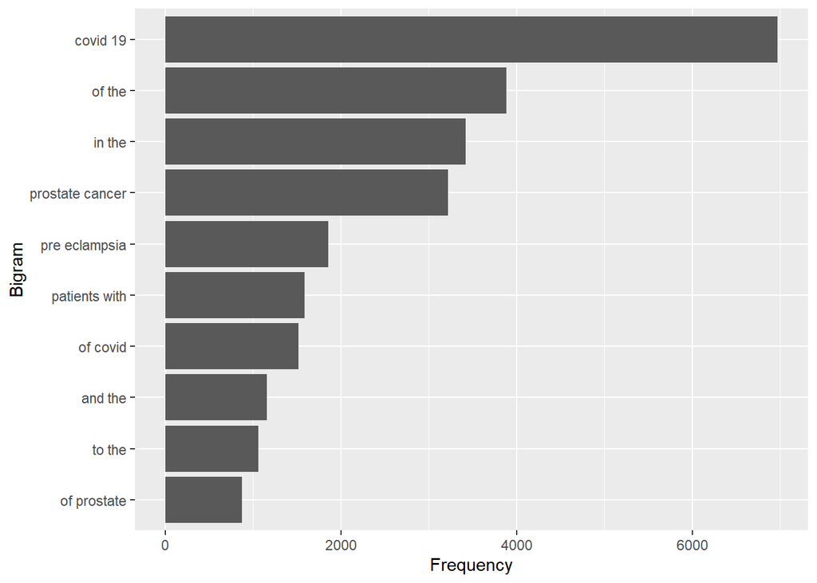

   ```r
   pubmed |>
     unnest_ngrams(ngram, abstract, n = 2) |>
     count(ngram, sort = TRUE) |>
     top_n(10, n) |>
     ggplot(aes(n, fct_reorder(ngram, n))) +
     geom_col() +
     labs(x = "Frequency", y = "Bigram")
   ```

3. Calculate the TF-IDF value for each word-search term combination (here you want the search term to be the “document”). What are the 5 tokens from each search term with the highest TF-IDF value? How are the results different from the answers you got in question 1?

   ```r
   pubmed |>
     unnest_tokens(token, abstract) |>
     count(token, term) |>
     bind_tf_idf(token, term, n) |>
     group_by(term) |>
     top_n(5, tf_idf) |>
     arrange(term, desc(tf_idf))
   ```

   ```
   # A tibble: 25 × 6
   # Groups:   term [5]
      token       term                n      tf   idf  tf_idf
      <chr>       <chr>           <int>   <dbl> <dbl>   <dbl>
    1 covid       covid            7275 0.0371  1.61  0.0597
    2 pandemic    covid             800 0.00408 1.61  0.00657
    3 coronavirus covid             647 0.00330 1.61  0.00531
    4 sars        covid             372 0.00190 1.61  0.00305
    5 cov         covid             334 0.00170 1.61  0.00274
    6 cf          cystic fibrosis   625 0.0127  0.916 0.0117
    7 fibrosis    cystic fibrosis   867 0.0176  0.511 0.00901
    8 cystic      cystic fibrosis   862 0.0175  0.511 0.00896
    9 cftr        cystic fibrosis    86 0.00175 1.61  0.00282
   10 sweat       cystic fibrosis    83 0.00169 1.61  0.00272
   # ℹ 15 more rows
   ```

The top 5 tokens from each search term with the highest TF-IDF value are written below:

1. Covid: covid, pandemic, coronavirus, sars, cov
2. Cystic Fibrosis: cf, fibrosis, cystic, cftr, sweat
3. Meningitis: meningitis, meningeal, pachymeningitis, csf, meninges
4. Preeclampsia: eclampsia, preeclampsia, pregnancy, maternal, gestational
5. Prostate Cancer: prostate, androgen, psa, prostatectomy, castration

The results differ from the words we found in question 1. In question 1, the top 5 words for each search term were very general and many overlapped, such as “patient” and “disease”. However, after taking into account the TF-IDF, the top 5 words for each search term are a lot more specific to that search term and there are no overlapping words.

## Sentiment Analysis

1. Perform a sentiment analysis using the NRC lexicon. What is the most common sentiment for each search term? What if you remove `"positive"` and `"negative"` from the list?

   ```r
   library(textdata)
   # Citation: 'http://saifmohammad.com/WebDocs/Lexicons/NRC-Emotion-Lexicon.zip'

   pubmed |>
     unnest_tokens(word, abstract) |>
     inner_join(get_sentiments('nrc'), by = "word") |>
     count(term, sentiment, sort = TRUE) |>
     group_by(term) |>
     top_n(1, n)
   ```

   ```
   # A tibble: 5 × 3
   # Groups:   term [5]
     term            sentiment     n
     <chr>           <chr>     <int>
   1 covid           positive   9874
   2 prostate cancer negative   8918
   3 preeclampsia    positive   8014
   4 cystic fibrosis positive   2747
   5 meningitis      negative   2111
   ```

   ```r
   nrc_fun <- get_sentiments("nrc")
   nrc_fun <- nrc_fun[!nrc_fun$sentiment %in% c("positive","negative"), ]

   pubmed |>
     unnest_tokens(word, abstract) |>
     inner_join(nrc_fun) |>
     count(term, sentiment, sort = TRUE) |>
     group_by(term) |>
     top_n(1, n)
   ```

   ```
   # A tibble: 5 × 3
   # Groups:   term [5]
     term            sentiment        n
     <chr>           <chr>        <int>
   1 prostate cancer fear          8118
   2 covid           fear          7730
   3 preeclampsia    anticipation  4780
   4 cystic fibrosis disgust       1714
   5 meningitis      fear          1510
   ```

   The most common sentiment for covid, preeclampsia, and cystic fibrosis is positive, while the most common sentiment for prostate cancer and meningitis is negative. After removing positive and negative from the nrc list, the top sentiment for prostate cancer, covid, and meningitis is fear. The top sentiment for preeclampsia and cystic fibrosis is anticipation and disgust, respectively.
2. Now perform a sentiment analysis using the AFINN lexicon to get an average positivity score for each abstract (hint: you may want to create a variable that indexes, or counts, the abstracts). Create a visualization that shows these scores grouped by search term. Are any search terms noticeably different from the others?

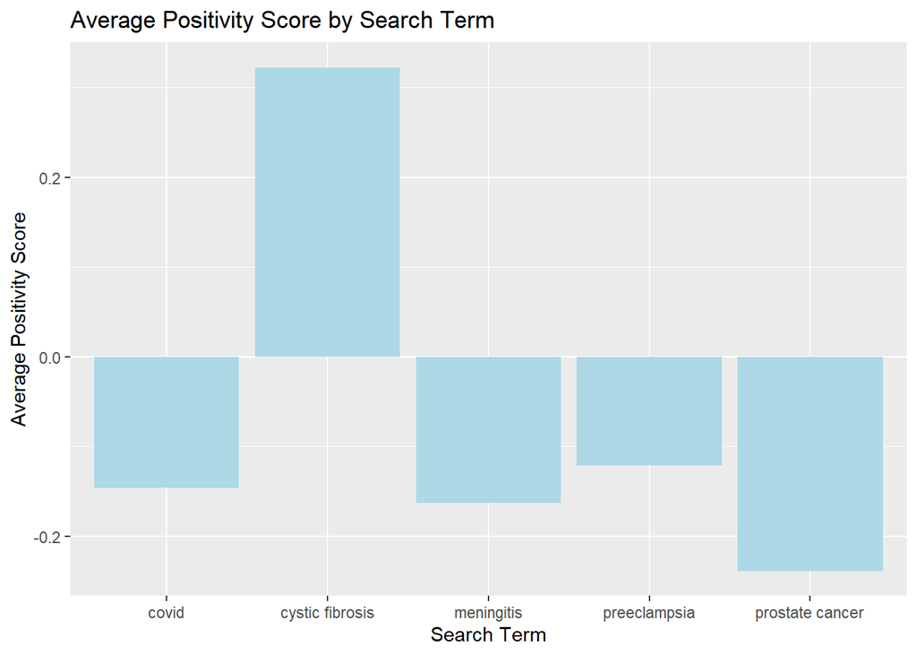

   ```r
   # Citation: http://www2.imm.dtu.dk/pubdb/views/publication_details.php?id=6010

   abstractscores <- pubmed |>
     mutate(abstract_num = row_number()) |>
     unnest_tokens(word, abstract) |>
     inner_join(get_sentiments('afinn'), by = "word") |>
     group_by(abstract_num, term) |>
     summarize(avg_score = mean(value, na.rm = TRUE))
   termscores <- abstractscores |>
     group_by(term) |>
     summarize(
       avg_termscore = mean(avg_score, na.rm = TRUE))

   ggplot(termscores, aes(x = term, y = avg_termscore)) +
         geom_col(fill = "lightblue") +
         labs(title = "Average Positivity Score by Search Term",
              x = "Search Term",
              y = "Average Positivity Score")
   ```

Cystic fibrosis is the only search term with a positive average positivity score. The other terms have negative average positivity scores.